# Child Malnutrition in Africa, with a Focus on Ghana

From the continent, to Ghana, to its 16 regions

Kingsley Amegah

June 2026

# 1 Introduction

Malnutrition remains one of the defining health challenges in Africa, but the picture is far from uniform. This report zooms in across three levels: where **Ghana sits among African countries**, how malnutrition has **changed within Ghana**, and how it is **distributed across Ghana’s 16 regions** and social groups. Ghana is an instructive case: a relative success story on chronic undernutrition that still carries sharp internal inequalities.

The headline indicator is **stunting** (low height-for-age, the standard measure of chronic child undernutrition), complemented by underweight, wasting, overweight and anaemia.

# 2 Data and methods

All data come from open sources, with no API keys required:

- **DHS Program API** - Ghana stunting by region and by wealth, education and residence, across survey rounds (1993-2022).
- **World Bank Open Data API** - malnutrition indicators for African countries and Ghana’s national trend.
- **geoBoundaries** - Ghana’s administrative (region) boundaries for mapping.

Analysis is descriptive and equity-focused: continental benchmarking, national trends, a regional choropleth, and disparity ratios across social groups.

```r
afr   <- read_csv("data/africa_stunting_latest.csv", show_col_types = FALSE)
trend <- read_csv("data/ghana_trend.csv", show_col_types = FALSE)
region<- read_csv("data/ghana_stunting_region.csv", show_col_types = FALSE)
equity<- read_csv("data/ghana_equity.csv", show_col_types = FALSE)
gh_sf <- st_read("data/ghana_adm1.geojson", quiet = TRUE) |>
  mutate(region = str_remove(shapeName, " Region$"))
```

# 3 Africa context: where does Ghana stand?

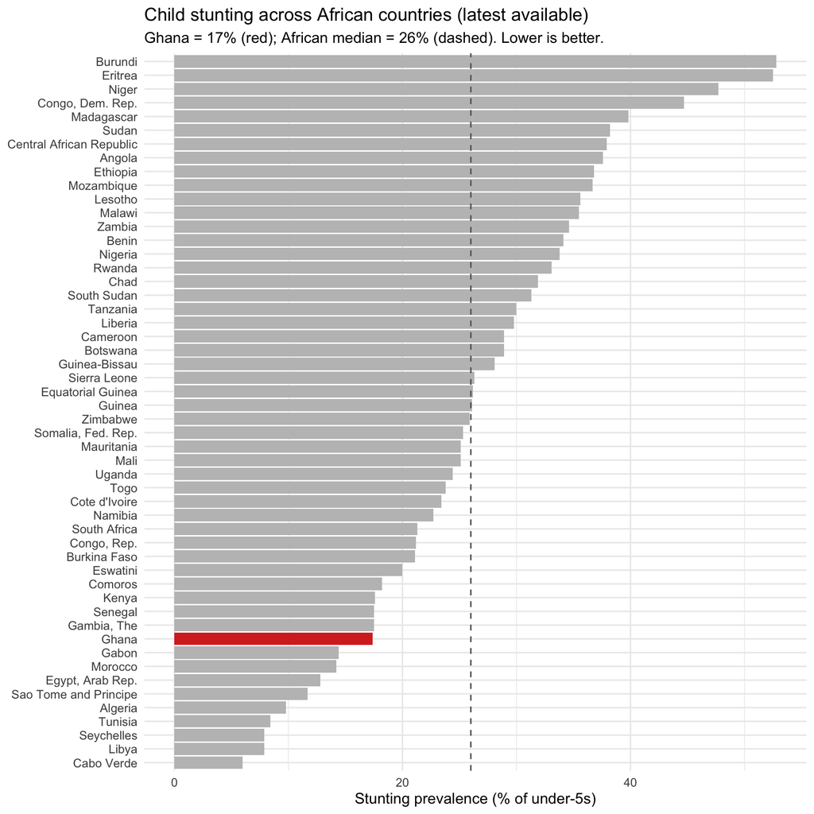

```r
afr <- afr |> mutate(is_ghana = iso3 == "GHA")
ghana_val <- afr$value[afr$iso3 == "GHA"]
afr_median <- median(afr$value)
ggplot(afr, aes(value, fct_reorder(country, value), fill = is_ghana)) +
  geom_col() +
  geom_vline(xintercept = afr_median, linetype = "dashed", colour = "grey40") +
  scale_fill_manual(values = c(`FALSE` = "grey75", `TRUE` = HI), guide = "none") +
  labs(title = "Child stunting across African countries (latest available)",
       subtitle = sprintf("Ghana = %.0f%% (red); African median = %.0f%% (dashed). Lower is better.",
                          ghana_val, afr_median),
       x = "Stunting prevalence (% of under-5s)", y = NULL)
```

Ghana’s stunting prevalence (17%) is **well below the African median** of 26%, placing it among the continent’s stronger performers on chronic undernutrition.

# 4 Ghana over time: progress and the double burden

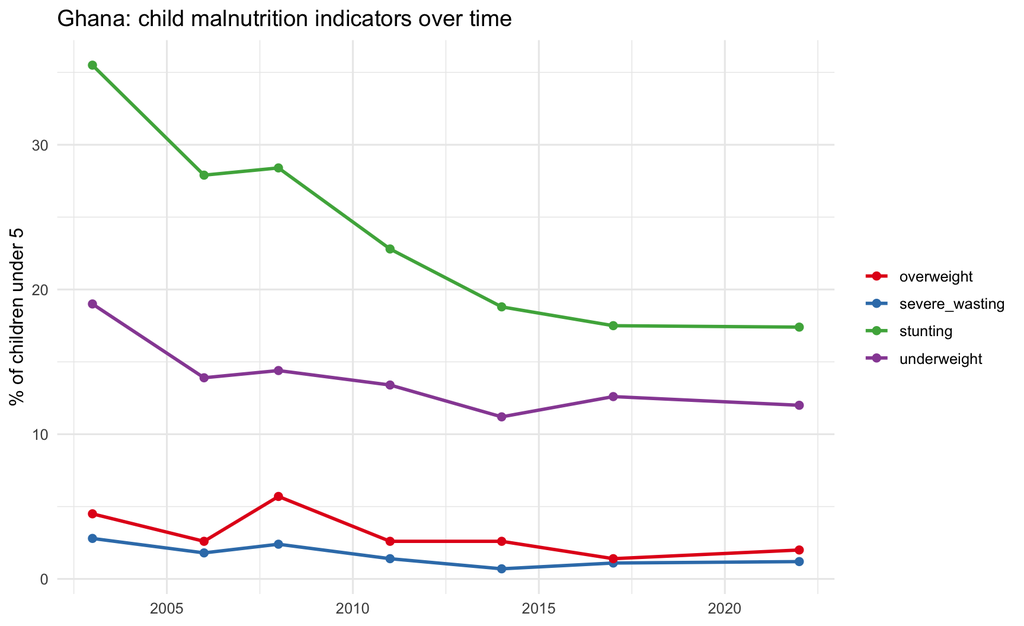

```r
trend |>
  filter(indicator %in% c("stunting", "underweight", "overweight", "severe_wasting")) |>
  ggplot(aes(year, value, colour = indicator)) +
  geom_line(linewidth = 1) + geom_point(size = 2) +
  scale_colour_brewer(palette = "Set1") +
  labs(title = "Ghana: child malnutrition indicators over time",
       x = NULL, y = "% of children under 5", colour = NULL)
```

Chronic undernutrition (stunting, underweight) has fallen substantially, yet **wasting has not disappeared and overweight persists** - the early signs of a “double burden” of malnutrition that increasingly characterises middle-income transitions.

# 5 Within Ghana: the regional divide

We map stunting across Ghana’s 16 regions using the most recent survey (2022). DHS reports a mix of old and new regions; we select the 16 current regions and match them to the boundary file.

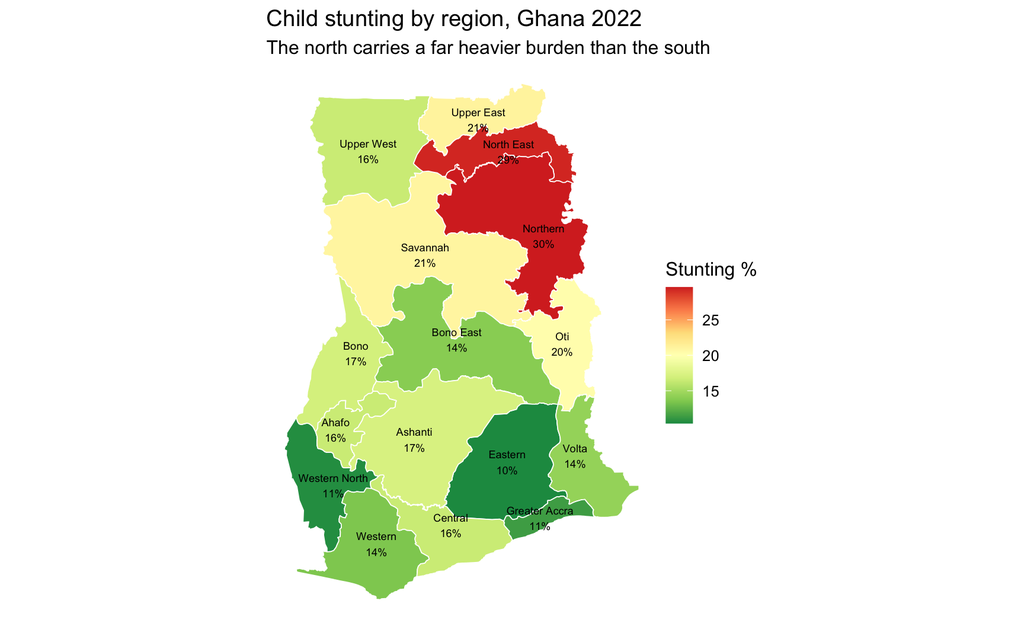

```r
# Map DHS 2022 leaf labels -> boundary region names
m <- c("..Western (post 2022)"="Western", "..Western North"="Western North",
       "Central"="Central", "Greater Accra"="Greater Accra",
       "..Volta (post 2022)"="Volta", "..Oti"="Oti", "Eastern"="Eastern",
       "Ashanti"="Ashanti", "..Ahafo"="Ahafo", "..Bono"="Bono",
       "..Bono East"="Bono East", "....Northern(post 2022)"="Northern",
       "....Savannah"="Savannah", "....Northeast"="North East",
       "..Upper East"="Upper East", "..Upper West"="Upper West")
reg22 <- region |> filter(survey_year == 2022, label %in% names(m)) |>
  mutate(region = m[label]) |> select(region, stunting = value)

map_df <- gh_sf |> left_join(reg22, by = "region")
ggplot(map_df) +
  geom_sf(aes(fill = stunting), colour = "white", linewidth = 0.3) +
  scale_fill_distiller(palette = "RdYlGn", direction = -1, name = "Stunting %") +
  geom_sf_text(aes(label = paste0(region, "\n", round(stunting), "%")), size = 2.4) +
  labs(title = "Child stunting by region, Ghana 2022",
       subtitle = "The north carries a far heavier burden than the south") +
  theme_void(base_size = 12)
```

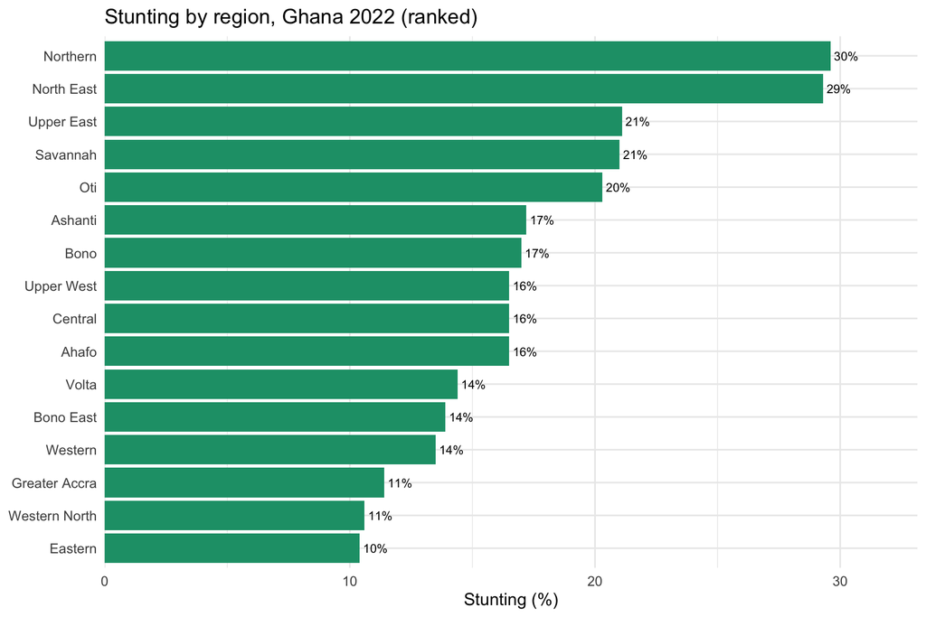

```r
reg22 |>
  ggplot(aes(stunting, fct_reorder(region, stunting))) +
  geom_col(fill = ACC) +
  geom_text(aes(label = paste0(round(stunting), "%")), hjust = -0.15, size = 3) +
  scale_x_continuous(expand = expansion(mult = c(0, 0.12))) +
  labs(title = "Stunting by region, Ghana 2022 (ranked)",
       x = "Stunting (%)", y = NULL)
```

The gap is stark: stunting ranges from about **10% in Eastern** to **30% in Northern** - a 2.8-fold difference between the best and worst regions, reflecting Ghana’s well-documented north-south divide.

# 6 Inequality by wealth, education and residence

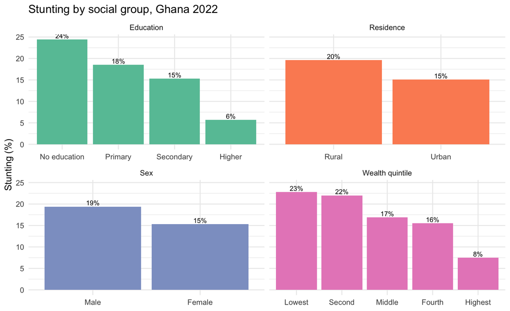

```r
eq <- equity |>
  filter(survey_year == 2022, indicator == "stunting",
         category %in% c("Wealth quintile", "Education", "Residence", "Sex")) |>
  mutate(label = factor(label, levels = c(
    "Lowest","Second","Middle","Fourth","Highest",
    "No education","Primary","Secondary","Higher",
    "Rural","Urban","Male","Female")))
ggplot(eq, aes(label, value, fill = category)) +
  geom_col(show.legend = FALSE) +
  geom_text(aes(label = paste0(round(value), "%")), vjust = -0.3, size = 3) +
  facet_wrap(~ category, scales = "free_x") +
  scale_fill_brewer(palette = "Set2") +
  labs(title = "Stunting by social group, Ghana 2022",
       x = NULL, y = "Stunting (%)")
```

The social gradient is steep. Children in the **poorest** wealth quintile are about **3 times** as likely to be stunted as those in the **richest** (23% vs 8%), and children of mothers with **no education** are around **4.3 times** as likely as those whose mothers have higher education. Rural children fare worse than urban ones. These gaps show that national averages hide who is being left behind.

# 7 Conclusion and limitations

**Limitations.** Survey estimates carry sampling error and are collected only every few years; region definitions changed in 2019, complicating long-run regional comparisons; and this is an ecological, descriptive analysis, so associations should not be read as causal.

*Built in R (tidyverse, sf, ggplot2) from DHS, World Bank and geoBoundaries open data. Author: Kingsley Amegah.*